# MSE Setup

Jonathan J. Deroba

2025-04-16

# Setup

Following the MSE vignette from Chengxue Li at https://lichengxue.github.io/whamMSE/

## Modify for short-lived

Basic info for a short-lived species. Based on Wiedenmann et al. (2017), Table 3 B and C.

A short-lived species recruits at 1 year, lives to 7, mean M is 0.4, 50% mature at age 2 (1.75 in Wiedenmann).

Modify from https://lichengxue.github.io/whamMSE/03.Management-Strategy-Evaluation.html

Historical fishing pattern is “F-H-L”.

Setup the ideal baseline with assessments 2 years, both surveys, and “good” data.

Now set up as in new Single Stock MSE vignette: https://lichengxue.github.io/whamMSE/11.Single-Stock-MSE.html

```
##
##  Note: n_stocks, n_regions, n_fleets, n_indices are not the same.
```

Movement, do we need this? 1 stock 1 region model, turn it off

Adjust for 1 area 1 stock, short lived M=0.4

Make inputs for the OM

[output not shown]

Make the OM

One dataset

```
##
## Now simulating data
```

Assessment specifications, every 2 years as a start, MP could be annual

Try a simple EM, looks like EM1 [here](https://lichengxue.github.io/whamMSE/03.Management-Strategy-Evaluation.html#10_Description_of_assessment_models:)

[output not shown]

```
## Catch Advice
##  303411.5 344194.7
##
## Now calculating F at age in the OM given the catch advice...
##
## Now calculating fleet-specific F in year  31
```

```
##
## Fishing mortality is  1.079683
##
## Now updating F in OM for year  31
##
## Now simulating data for year  31
##
## Now projecting data for years after  31
##
## Now calculating fleet-specific F in year  32
##
## Fishing mortality is  0.9755246
##
## Now updating F in OM for year  32
##
## Now simulating data for year  32
##
## Now projecting data for years after  32
##
## Now conducting stock assessment for year 32
##
##  Note: n_stocks, n_regions, n_fleets, n_indices are not the same.
## [1] "start"
## [1] "basic_info"
## [1] "catch"
## [1] "indices"
## [1] "WAA"
## [1] "NAA"
## [1] "q"
## [1] "selectivity"
## [1] "age_comp"
## [1] "F"
## [1] "M"
## [1] "move"
## [1] "L"
## [1] "ecov"
## [1] "osa_obs"
##
##  NOTE: WHAM version 2.0.0 and forward makes major changes to the structure of some data, parameters, and reported objects.
##  NOTE: WHAM version 2.0.0 and forward decouples random effects for recruitment and random effects for older ages by default.
```

[output cut: 18 more lines]

```
##
## $eval.max
## [1] 1000
##
##
## Now checking convergence of assessment model...
##
## Assessment model is converged.
##
## Now generating catch advice...
##
## Harvest Control Rule type 1
## NAA:
##
##  Same NAA_re$sigma being used for all stocks (rec+1).
```

```
## Catch Advice
##  340168.4 490421.7
##
## Now calculating F at age in the OM given the catch advice...
##
## Now calculating fleet-specific F in year  33
##
## Fishing mortality is  0.5949165
##
## Now updating F in OM for year  33
##
## Now simulating data for year  33
##
## Now projecting data for years after  33
##
## Now calculating fleet-specific F in year  34
##
## Fishing mortality is  1.074096
##
## Now updating F in OM for year  34
##
## Now simulating data for year  34
##
## Now projecting data for years after  34
##
## Now conducting stock assessment for year 34
##
##  Note: n_stocks, n_regions, n_fleets, n_indices are not the same.
## [1] "start"
## [1] "basic_info"
## [1] "catch"
## [1] "indices"
## [1] "WAA"
## [1] "NAA"
## [1] "q"
## [1] "selectivity"
## [1] "age_comp"
## [1] "F"
## [1] "M"
## [1] "move"
```

[output cut: 24 more lines]

```
##
## $eval.max
## [1] 1000
##
##
## Now checking convergence of assessment model...
##
## Assessment model is converged.
##
## Now generating catch advice...
##
## Harvest Control Rule type 1
## NAA:
##
##  Same NAA_re$sigma being used for all stocks (rec+1).
```

```
## Catch Advice
##  251012.1 282685
##
## Now calculating F at age in the OM given the catch advice...
##
## Now calculating fleet-specific F in year  35
##
## Fishing mortality is  0.6623231
##
## Now updating F in OM for year  35
##
## Now simulating data for year  35
##
## Now projecting data for years after  35
##
## Now calculating fleet-specific F in year  36
##
## Fishing mortality is  0.8074256
##
## Now updating F in OM for year  36
##
## Now simulating data for year  36
##
## Now projecting data for years after  36
##
## Now conducting stock assessment for year 36
##
##  Note: n_stocks, n_regions, n_fleets, n_indices are not the same.
## [1] "start"
## [1] "basic_info"
## [1] "catch"
## [1] "indices"
## [1] "WAA"
## [1] "NAA"
## [1] "q"
## [1] "selectivity"
## [1] "age_comp"
## [1] "F"
## [1] "M"
## [1] "move"
```

[output cut: 24 more lines]

```
##
## $eval.max
## [1] 1000
##
##
## Now checking convergence of assessment model...
##
## Assessment model is converged.
##
## Now generating catch advice...
##
## Harvest Control Rule type 1
## NAA:
##
##  Same NAA_re$sigma being used for all stocks (rec+1).
```

```
## Catch Advice
##  251038 361243.5
##
## Now calculating F at age in the OM given the catch advice...
##
## Now calculating fleet-specific F in year  37
##
## Fishing mortality is  0.593641
##
## Now updating F in OM for year  37
##
## Now simulating data for year  37
##
## Now projecting data for years after  37
##
## Now calculating fleet-specific F in year  38
##
## Fishing mortality is  0.7688336
##
## Now updating F in OM for year  38
##
## Now simulating data for year  38
##
## Now projecting data for years after  38
##
## Now conducting stock assessment for year 38
##
##  Note: n_stocks, n_regions, n_fleets, n_indices are not the same.
## [1] "start"
## [1] "basic_info"
## [1] "catch"
## [1] "indices"
## [1] "WAA"
## [1] "NAA"
## [1] "q"
## [1] "selectivity"
## [1] "age_comp"
## [1] "F"
## [1] "M"
## [1] "move"
```

[output cut: 24 more lines]

```
##
## $eval.max
## [1] 1000
##
##
## Now checking convergence of assessment model...
##
## Assessment model is converged.
##
## Now generating catch advice...
##
## Harvest Control Rule type 1
## NAA:
##
##  Same NAA_re$sigma being used for all stocks (rec+1).
```

```
## Catch Advice
##  320746.2 384584
##
## Now calculating F at age in the OM given the catch advice...
##
## Now calculating fleet-specific F in year  39
##
## Fishing mortality is  0.6399368
##
## Now updating F in OM for year  39
##
## Now simulating data for year  39
##
## Now projecting data for years after  39
##
## Now calculating fleet-specific F in year  40
##
## Fishing mortality is  0.8946355
##
## Now updating F in OM for year  40
##
## Now simulating data for year  40
##
## Now projecting data for years after  40
## Please ignore Warning in check_projF(proj_mod).
## Total Runtime =  46.10361
```

Try same model with poorer survey in the future

See https://lichengxue.github.io/whamMSE/15.Reduce-Data-Availability-In-Assessment.html#6_Increase_observation_error_and_reduce_sample_size_for_survey_indices_in_the_feedback_period

Generate new om and dataset, keep same assessment interval as above

```
##
## Now simulating data
```

Run new loop

[output not shown]

```
## Catch Advice
##  788370.8 839481.7
##
## Now calculating F at age in the OM given the catch advice...
##
## Now calculating fleet-specific F in year  31
##
## Fishing mortality is  6.184324
##
## Now updating F in OM for year  31
##
## Now simulating data for year  31
##
## Now projecting data for years after  31
##
## Now calculating fleet-specific F in year  32
##
## Fishing mortality is  10
##
## Now updating F in OM for year  32
##
## Now simulating data for year  32
##
## Now projecting data for years after  32
##
## Now conducting stock assessment for year 32
##
##  Note: n_stocks, n_regions, n_fleets, n_indices are not the same.
## [1] "start"
## [1] "basic_info"
## [1] "catch"
## [1] "indices"
## [1] "WAA"
## [1] "NAA"
## [1] "q"
## [1] "selectivity"
## [1] "age_comp"
## [1] "F"
## [1] "M"
## [1] "move"
```

[output cut: 24 more lines]

```
##
## $eval.max
## [1] 1000
##
##
## Now checking convergence of assessment model...
##
## Assessment model is converged.
##
## Now generating catch advice...
##
## Harvest Control Rule type 1
## NAA:
##
##  Same NAA_re$sigma being used for all stocks (rec+1).
```

```
## Catch Advice
##  42385.1 97682.62
##
## Now calculating F at age in the OM given the catch advice...
##
## Now calculating fleet-specific F in year  33
##
## Fishing mortality is  1.352024
##
## Now updating F in OM for year  33
##
## Now simulating data for year  33
##
## Now projecting data for years after  33
##
## Now calculating fleet-specific F in year  34
##
## Fishing mortality is  2.276308
##
## Now updating F in OM for year  34
##
## Now simulating data for year  34
##
## Now projecting data for years after  34
##
## Now conducting stock assessment for year 34
##
##  Note: n_stocks, n_regions, n_fleets, n_indices are not the same.
## [1] "start"
## [1] "basic_info"
## [1] "catch"
## [1] "indices"
## [1] "WAA"
## [1] "NAA"
## [1] "q"
## [1] "selectivity"
## [1] "age_comp"
## [1] "F"
## [1] "M"
## [1] "move"
```

[output cut: 24 more lines]

```
##
## $eval.max
## [1] 1000
##
##
## Now checking convergence of assessment model...
##
## Assessment model is converged.
##
## Now generating catch advice...
##
## Harvest Control Rule type 1
## NAA:
##
##  Same NAA_re$sigma being used for all stocks (rec+1).
```

```
## Catch Advice
##  42403.21 97458.94
##
## Now calculating F at age in the OM given the catch advice...
##
## Now calculating fleet-specific F in year  35
##
## Fishing mortality is  0.3452335
##
## Now updating F in OM for year  35
##
## Now simulating data for year  35
##
## Now projecting data for years after  35
##
## Now calculating fleet-specific F in year  36
##
## Fishing mortality is  0.3997408
##
## Now updating F in OM for year  36
##
## Now simulating data for year  36
##
## Now projecting data for years after  36
##
## Now conducting stock assessment for year 36
##
##  Note: n_stocks, n_regions, n_fleets, n_indices are not the same.
## [1] "start"
## [1] "basic_info"
## [1] "catch"
## [1] "indices"
## [1] "WAA"
## [1] "NAA"
## [1] "q"
## [1] "selectivity"
## [1] "age_comp"
## [1] "F"
## [1] "M"
## [1] "move"
```

[output cut: 24 more lines]

```
##
## $eval.max
## [1] 1000
##
##
## Now checking convergence of assessment model...
##
## Assessment model is converged.
##
## Now generating catch advice...
##
## Harvest Control Rule type 1
## NAA:
##
##  Same NAA_re$sigma being used for all stocks (rec+1).
```

```
## Catch Advice
##  112427.1 179565.1
##
## Now calculating F at age in the OM given the catch advice...
##
## Now calculating fleet-specific F in year  37
##
## Fishing mortality is  0.2531761
##
## Now updating F in OM for year  37
##
## Now simulating data for year  37
##
## Now projecting data for years after  37
##
## Now calculating fleet-specific F in year  38
##
## Fishing mortality is  0.2850604
##
## Now updating F in OM for year  38
##
## Now simulating data for year  38
##
## Now projecting data for years after  38
##
## Now conducting stock assessment for year 38
##
##  Note: n_stocks, n_regions, n_fleets, n_indices are not the same.
## [1] "start"
## [1] "basic_info"
## [1] "catch"
## [1] "indices"
## [1] "WAA"
## [1] "NAA"
## [1] "q"
## [1] "selectivity"
## [1] "age_comp"
## [1] "F"
## [1] "M"
## [1] "move"
```

[output cut: 24 more lines]

```
##
## $eval.max
## [1] 1000
##
##
## Now checking convergence of assessment model...
##
## Assessment model is converged.
##
## Now generating catch advice...
##
## Harvest Control Rule type 1
## NAA:
##
##  Same NAA_re$sigma being used for all stocks (rec+1).
```

```
## Catch Advice
##  360023.5 400392
##
## Now calculating F at age in the OM given the catch advice...
##
## Now calculating fleet-specific F in year  39
##
## Fishing mortality is  0.4775305
##
## Now updating F in OM for year  39
##
## Now simulating data for year  39
##
## Now projecting data for years after  39
##
## Now calculating fleet-specific F in year  40
##
## Fishing mortality is  0.6147726
##
## Now updating F in OM for year  40
##
## Now simulating data for year  40
##
## Now projecting data for years after  40
## Please ignore Warning in check_projF(proj_mod).
## Total Runtime =  42.33611
```

Visualize 2 mods (modified from https://lichengxue.github.io/whamMSE/03.Management-Strategy-Evaluation.html#12_Compare_model_performance)

This compares a good survey in the future (1) with a poor survey in the future (2)

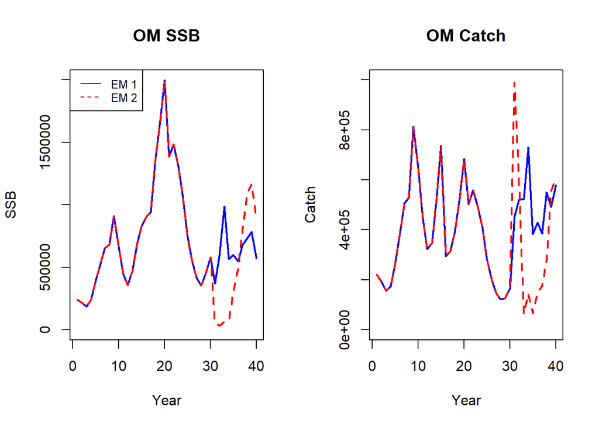

Now add the one with no survey, from Cheng’s code

Generate new om and dataset, keep same assessment interval as above

```
##
## Now simulating data
```

Run new loop

[output not shown]

```
## Catch Advice
##  1470154 1614942
##
## Now calculating F at age in the OM given the catch advice...
##
## Now calculating fleet-specific F in year  31
##
## Fishing mortality is  10
##
## Now updating F in OM for year  31
##
## Now simulating data for year  31
##
## Now projecting data for years after  31
##
## Now calculating fleet-specific F in year  32
##
## Fishing mortality is  10
##
## Now updating F in OM for year  32
##
## Now simulating data for year  32
##
## Now projecting data for years after  32
##
## Now conducting stock assessment for year 32
##
##  Note: n_stocks, n_regions, n_fleets, n_indices are not the same.
## [1] "start"
## [1] "basic_info"
## [1] "catch"
## [1] "indices"
## [1] "WAA"
## [1] "NAA"
## [1] "q"
## [1] "selectivity"
## [1] "age_comp"
## [1] "F"
## [1] "M"
## [1] "move"
```

[output cut: 24 more lines]

```
##
## $eval.max
## [1] 1000
##
##
## Now checking convergence of assessment model...
##
## Assessment model is converged.
##
## Now generating catch advice...
##
## Harvest Control Rule type 1
## NAA:
##
##  Same NAA_re$sigma being used for all stocks (rec+1).
```

```
## Catch Advice
##  16161.54 48274.09
##
## Now calculating F at age in the OM given the catch advice...
##
## Now calculating fleet-specific F in year  33
##
## Fishing mortality is  0.5772992
##
## Now updating F in OM for year  33
##
## Now simulating data for year  33
##
## Now projecting data for years after  33
##
## Now calculating fleet-specific F in year  34
##
## Fishing mortality is  0.8366779
##
## Now updating F in OM for year  34
##
## Now simulating data for year  34
##
## Now projecting data for years after  34
##
## Now conducting stock assessment for year 34
##
##  Note: n_stocks, n_regions, n_fleets, n_indices are not the same.
## [1] "start"
## [1] "basic_info"
## [1] "catch"
## [1] "indices"
## [1] "WAA"
## [1] "NAA"
## [1] "q"
## [1] "selectivity"
## [1] "age_comp"
## [1] "F"
## [1] "M"
## [1] "move"
```

[output cut: 24 more lines]

```
##
## $eval.max
## [1] 1000
##
##
## Now checking convergence of assessment model...
##
## Assessment model is converged.
##
## Now generating catch advice...
##
## Harvest Control Rule type 1
## NAA:
##
##  Same NAA_re$sigma being used for all stocks (rec+1).
```

```
## Catch Advice
##  157645.3 295701.3
##
## Now calculating F at age in the OM given the catch advice...
##
## Now calculating fleet-specific F in year  35
##
## Fishing mortality is  0.9775418
##
## Now updating F in OM for year  35
##
## Now simulating data for year  35
##
## Now projecting data for years after  35
##
## Now calculating fleet-specific F in year  36
##
## Fishing mortality is  1.379152
##
## Now updating F in OM for year  36
##
## Now simulating data for year  36
##
## Now projecting data for years after  36
##
## Now conducting stock assessment for year 36
##
##  Note: n_stocks, n_regions, n_fleets, n_indices are not the same.
## [1] "start"
## [1] "basic_info"
## [1] "catch"
## [1] "indices"
## [1] "WAA"
## [1] "NAA"
## [1] "q"
## [1] "selectivity"
## [1] "age_comp"
## [1] "F"
## [1] "M"
## [1] "move"
```

[output cut: 24 more lines]

```
##
## $eval.max
## [1] 1000
##
##
## Now checking convergence of assessment model...
##
## Assessment model is converged.
##
## Now generating catch advice...
##
## Harvest Control Rule type 1
## NAA:
##
##  Same NAA_re$sigma being used for all stocks (rec+1).
```

```
## Catch Advice
##  145804.4 243511.7
##
## Now calculating F at age in the OM given the catch advice...
##
## Now calculating fleet-specific F in year  37
##
## Fishing mortality is  0.5063108
##
## Now updating F in OM for year  37
##
## Now simulating data for year  37
##
## Now projecting data for years after  37
##
## Now calculating fleet-specific F in year  38
##
## Fishing mortality is  0.6024605
##
## Now updating F in OM for year  38
##
## Now simulating data for year  38
##
## Now projecting data for years after  38
##
## Now conducting stock assessment for year 38
##
##  Note: n_stocks, n_regions, n_fleets, n_indices are not the same.
## [1] "start"
## [1] "basic_info"
## [1] "catch"
## [1] "indices"
## [1] "WAA"
## [1] "NAA"
## [1] "q"
## [1] "selectivity"
## [1] "age_comp"
## [1] "F"
## [1] "M"
## [1] "move"
```

[output cut: 24 more lines]

```
##
## $eval.max
## [1] 1000
##
##
## Now checking convergence of assessment model...
##
## Assessment model is converged.
##
## Now generating catch advice...
##
## Harvest Control Rule type 1
## NAA:
##
##  Same NAA_re$sigma being used for all stocks (rec+1).
```

```
## Catch Advice
##  300912.8 382122.1
##
## Now calculating F at age in the OM given the catch advice...
##
## Now calculating fleet-specific F in year  39
##
## Fishing mortality is  0.6002432
##
## Now updating F in OM for year  39
##
## Now simulating data for year  39
##
## Now projecting data for years after  39
##
## Now calculating fleet-specific F in year  40
##
## Fishing mortality is  0.8498157
##
## Now updating F in OM for year  40
##
## Now simulating data for year  40
##
## Now projecting data for years after  40
## Please ignore Warning in check_projF(proj_mod).
## Total Runtime =  48.14882
```

Visualize 3 mods (modified from https://lichengxue.github.io/whamMSE/03.Management-Strategy-Evaluation.html#12_Compare_model_performance)

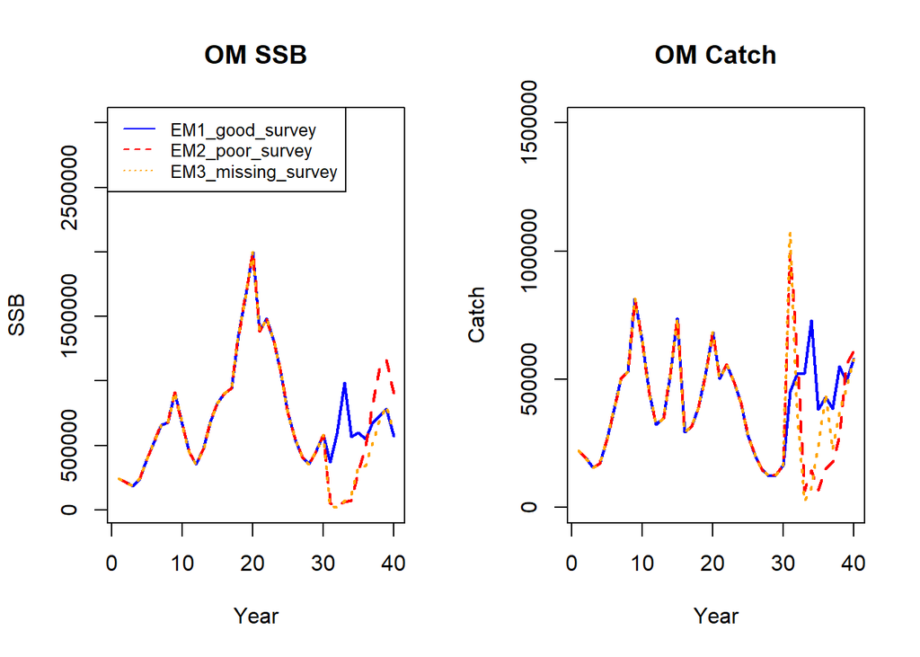

# References

Wiedenmann, J., Wilberg, M., Sylvia, A., and Miller, T. 2017. An evaluation of acceptable biological catch (ABC) harvest control rules designed to limit overfishing. Canadian Journal of Fisheries and Aquatic Sciences **74**(7): 1028–1040. doi:10.1139/cjfas-2016-0381.